# Workout Activity Prediction with Weight Lifting Exercises Dataset

activityPrediction.Rmd:

### A Project for the Coursera John Hopkins Machine Learning Class

### Prepared by Marcel Merchat

### February 1, 2016

## Unilateral Dumbell Biceps Curl Exercize

### An Analysis of a Human Activity Recognition Data Set (HAR)

## Overview:

### We will build a prediction model for recognizing correct weight lifting

### techniques using accelerometer data of the Human Activity

### Recognition Data Set (HAR) documented by Velloso et al. in a 2013 study.

### The performance of unilateral biceps curl exercise with dumbbells of

### six male subjects with little weight lifting experience was recorded

### using four accelerometers including three worn on the arm, glove, and

### belt and another on the dumbbell.

### The subjects performed one set of 10 repetitions of the biceps burl in

### five different ways using a relatively light dumbbell (1.25kg). They

### were graded as they were perfoming the curls as follows:

### Class A – Correctly according to the specification

### Class B – Throwing the elbows to the front

### Class C – Lifting the dumbbell halfway

### Class D – Lowering the dumbbell halfway

### Class E – Throwing the hips to the front

### While Class A corresponds to the correct way of doing exercise, all of

### the other classes correspond to common mistakes.

# Model Building

### The paper on the HAR study by Velloso et al. indicates that

### they used seventeen variables and calculated statistics to predict the

### same exercise classifications that we are concerned with. In contrast,

### we only use the stated data in the file for our predictions without

### statistics, but we are influenced by their list of seventeen

### parameters. We reduced the number of clean data columns from 60 to 38

### keeping many columns that pertained to list of seventeen statistics.

# Cross Validation

### The models were built using a Build data frame that was divided into

### training and testing parts. Finally for the project Quiz, the test data

### frame was set equal to the Quiz data which was used as Validation data.

# Sample Error

### Figure-1 below shows the accuracy for prediction outcomes.

### Figure-1 - Accuracy

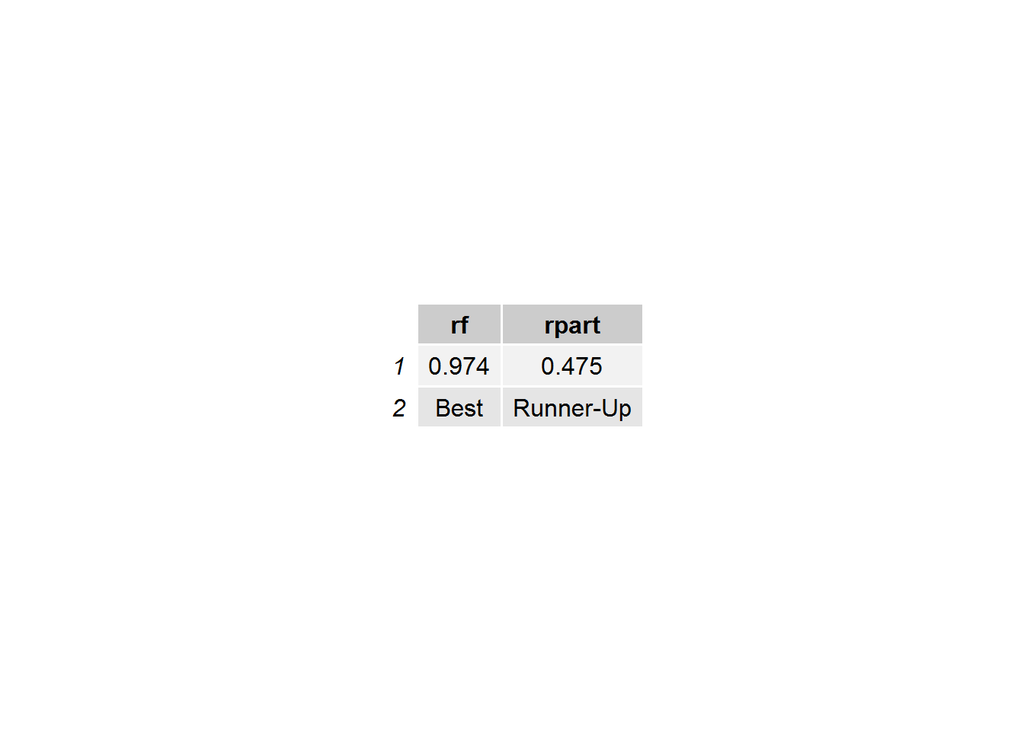

```r
grid.table(accuracy)
```

# Confusion Matrix

### Figure-2 below shows the confusion matrix for prediction outcomes.

### Figure-2 - Confusion Matrix

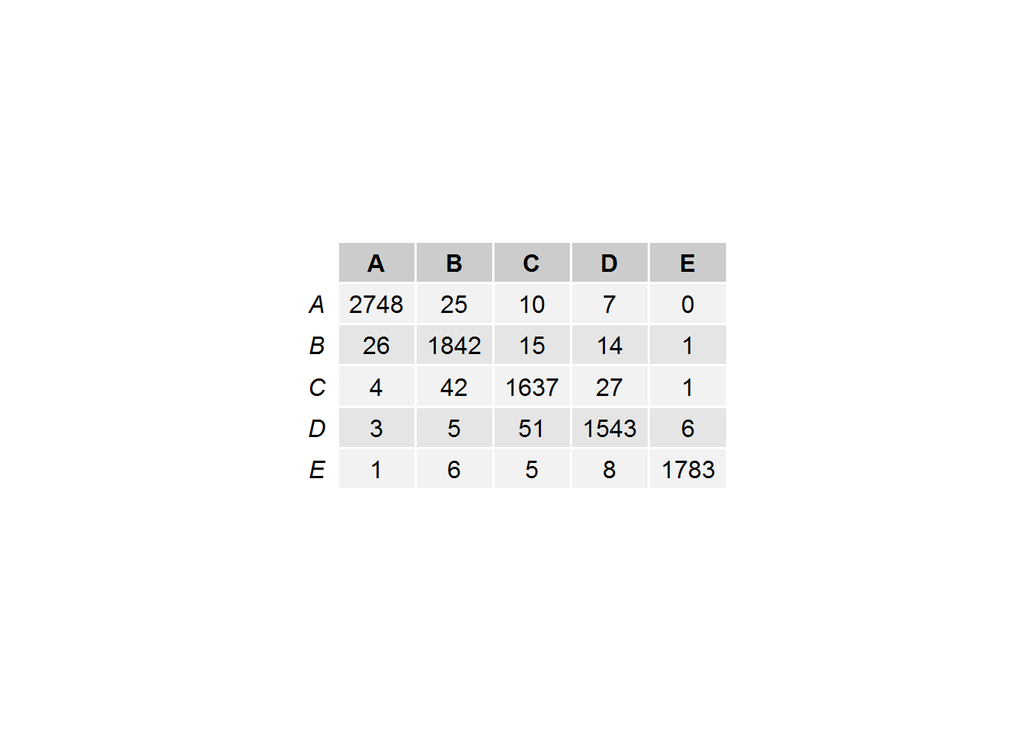

```r
grid.table(df_rf)
```

## Quiz Trial

### Figure-3 - Trial Run for Quiz Anwsers

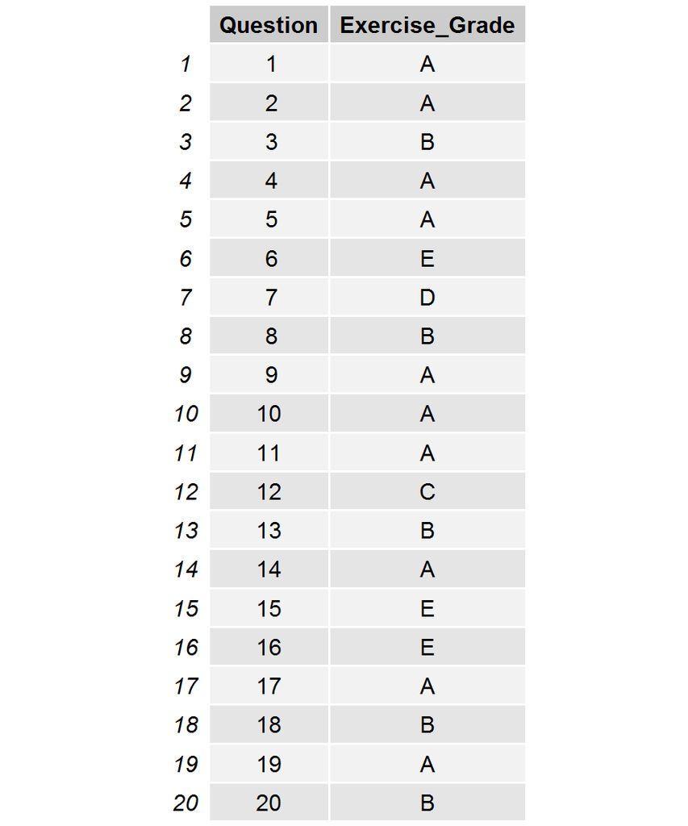

```r
grid.table(Test_Answers)
```

# Reference

### Velloso, E.; Bulling, A.; Gellersen, H.; Ugulino, W.; Fuks, H.

### Qualitative Activity Recognition of Weight Lifting Exercises.

### Proceedings of 4th International Conference in Cooperation with SIGCHI

### (Augmented Human ’13) . Stuttgart, Germany: ACM SIGCHI, 2013.